# act_report

## Report: act_report

### Introduction

The dataset that was used for this analysis and visualisation is the tweet archive of Twitter user[@dog_rates](https://twitter.com/dog_rates), also known as WeRateDogs. WeRateDogs is a Twitter account that rates people's dogs with a humorous comment about the dog. These ratings almost always have a denominator of 10. The numerators, though? Almost always greater than 10. 11/10, 12/10, 13/10, etc. Why? Because "[they're good dogs Brent.](https://knowyourmeme.com/memes/theyre-good-dogs-brent)" WeRateDogs has over 4 million followers and has received international media coverage.

This archive contains basic tweet data (tweet ID, timestamp, text, etc.) for all 5000+ of their tweets as they stood on August 1, 2017. [Udacity project overview](https://classroom.udacity.com/nanodegrees/nd002-alg-t2/parts/cd0015/modules/356d26d4-2237-46a0-ab78-e0ea93d9501a/lessons/ls2232/concepts/aa514310-e2cf-43d9-8165-aa6dd3b8472d)

[figure not shown]

Image Via [Boston Magazine](http://www.bostonmagazine.com/arts-entertainment/blog/2017/04/18/dog-rates-mit/)

### Insight#1:

Most dogs received a rating of 12/10 followed by 10/10 and 11/10 respectvely. This implies that WeRateDogs generally views the dogs whose photos have been uploaded as deserving of praise and that the account is quite forgiving and appreciative in the ratings it provides for the dogs.

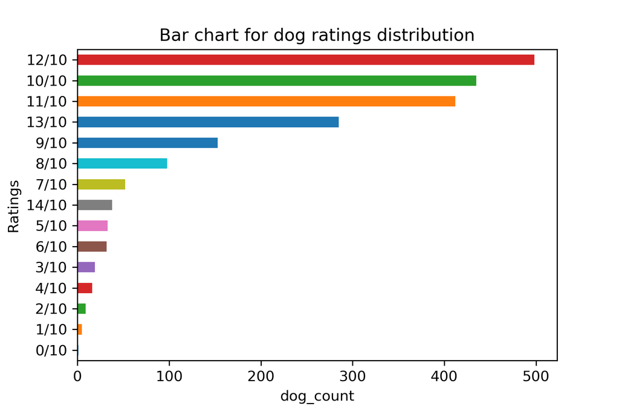

### Insight#2:

There are four dog stages in our dataset namely floofer, puppo, doggo and pupper. Most dogs are in the pupper stage followed by doggo, puppo and floofer respectively.

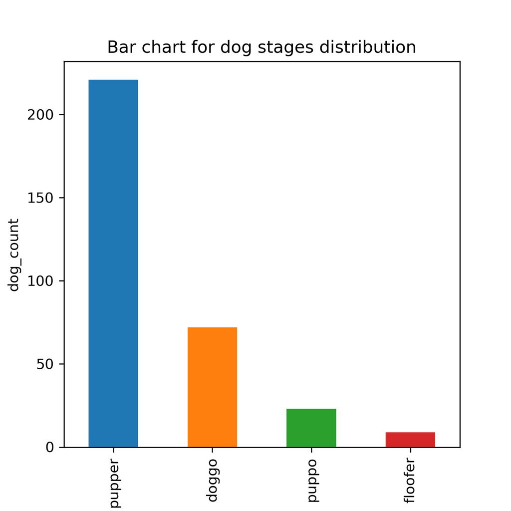

### Insight#3:

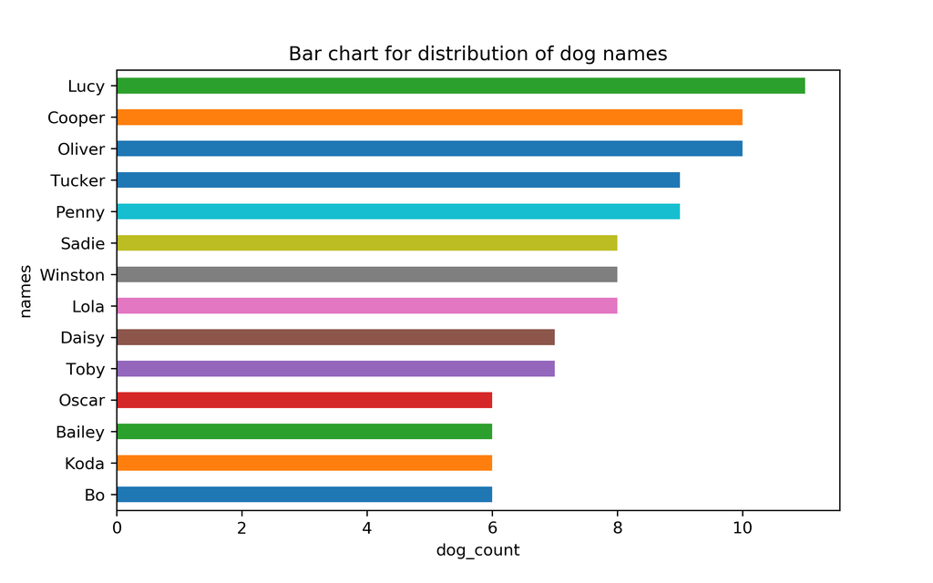